# Final Project – Join Data

Author

Preethika Makineni and Shea Li

Published

March 4, 2026

## Loading Data

```r
library(tidyverse)
breweries_df <- read.csv("breweries_df.csv")

computer_access_df <- read.csv("internet_access_df.csv")
```

## Part I: Find the Data

### First Dataset

#### Data source

https://data.census.gov/table/ACSST5Y2023.S2801?q=Internet+access+by+city+

This is a collection of data from the U.S. census detailing the types of computers and internet subscriptions by household per city. This source is reliable because it comes trom the U.S. census, and represents real household data.

#### Data Meaning

The table measures household internet access and types of computing devices for cities across the United States. It includes the number of households with computers, broadband, cellular internet, and other internet subscription types as well. This is our first data set.

#### Data Join

We intend to use city to join our data. The cities are listed a bit oddly, with the term “city” written out after every name. The name of the corresponding state is also listed under the same column, so this would have to be cleaned in order to have a successful join.

#### Data Observations

There are almost 700 rows in the data set. The columns consist of a numerical geographic marker, a column for the name of the geographical area, and then multiple columns detailing the total number of households that have computers of any kind, or just a tablet, or just a smartphone, etc.

Example Data Below:

```r
glimpse(computer_access_df)
```

```
Rows: 658
Columns: 127
$ GEO_ID         <chr> "Geography", "1600000US0103076", "1600000US0107000", "1…
$ NAME           <chr> "Geographic Area Name", "Auburn city, Alabama", "Birmin…
$ S2801_C01_001E <chr> "Estimate!!Total!!Total households", "30006", "91130", …
$ S2801_C01_001M <chr> "Margin of Error!!Total!!Total households", "2106", "33…
$ S2801_C01_002E <chr> "Estimate!!Total!!Total households!!TYPES OF COMPUTER!!…
$ S2801_C01_002M <chr> "Margin of Error!!Total!!Total households!!TYPES OF COM…
$ S2801_C01_003E <chr> "Estimate!!Total!!Total households!!TYPES OF COMPUTER!!…
$ S2801_C01_003M <chr> "Margin of Error!!Total!!Total households!!TYPES OF COM…
$ S2801_C01_004E <chr> "Estimate!!Total!!Total households!!TYPES OF COMPUTER!!…
$ S2801_C01_004M <chr> "Margin of Error!!Total!!Total households!!TYPES OF COM…
$ S2801_C01_005E <chr> "Estimate!!Total!!Total households!!TYPES OF COMPUTER!!…
$ S2801_C01_005M <chr> "Margin of Error!!Total!!Total households!!TYPES OF COM…
$ S2801_C01_006E <chr> "Estimate!!Total!!Total households!!TYPES OF COMPUTER!!…
```

[output cut: 114 more lines]

#### Data Issues

The columns other than the city names one are labeled a bit oddly, but they’re mostly legible and don’t seem to pose much of a problem since we do not plan on joining those. The titles of the data also seem to be doubly labeled, and some values will have to be removed for clarity once transferring numerical information, which will likely garner a warning from the system. Since this is census data, it does seem very reliable.

### Second Dataset

#### Data source

https://github.com/openbrewerydb/openbrewerydb/blob/master/breweries.csv

This is a listing of breweries by location from an open-source database hosted on github. There is an accompanying website for the dataset as well: https://www.openbrewerydb.org/. This source is reliable because all information in the dataset is pulled from verified sources such as satellite maps, representing real businesses.

#### Data Meaning

The table lists a comprehensive number of breweries around the United States. It operates in a different sphere than our first dataset in that it is not in the technology realm, but it does provide some insight into the culture of a given city. We hope to use these two datasets to see if the number of households with multiple computing devices has any correlation with the number of breweries in a city.

#### Data Join

We intend to use city to join our data. The cities are listed multiple times in this set, as it isn’t breweries per city but rather a list of breweries that have an assigned city location to each, so this information would have to be reformatted pre-joining. We also would only want cities listed in both datasets represented when joined, so we will have to figure that out as well.

#### Data Observations

There are 9083 rows in the data set. The columns consist of the location of the brewery (address and coordinates), the size of the brewery, the brewery’s name, and contact information (phone number and website).

Example Data Below:

```r
glimpse(breweries_df)
```

```
Rows: 9,083
Columns: 14
$ id             <chr> "5128df48-79fc-4f0f-8b52-d06be54d0cec", "9c5a66c8-cc13-…
$ name           <chr> "(405) Brewing Co", "(512) Brewing Co", "1 of Us Brewin…
$ brewery_type   <chr> "micro", "micro", "micro", "large", "large", "large", "…
$ address_1      <chr> "1716 Topeka St", "407 Radam Ln Ste F200", "8100 Washin…
$ address_2      <chr> "", "", "", "", "", "", "", "", "", "", "", "", "Botha'…
$ address_3      <chr> "", "", "", "", "", "", "", "", "", "", "", "", "", "",…
$ city           <chr> "Norman", "Austin", "Mount Pleasant", "Bend", "Bend", "…
$ state_province <chr> "Oklahoma", "Texas", "Wisconsin", "Oregon", "Oregon", "…
$ postal_code    <chr> "73069-8224", "78745-1197", "53406-3920", "97701-9847",…
$ country        <chr> "United States", "United States", "United States", "Uni…
$ phone          <chr> "4058160490", "5129211545", "2624847553", "5415851007",…
$ website_url    <chr> "http://www.405brewing.com", "http://www.512brewing.com…
$ longitude      <dbl> -97.468182, NA, -87.883364, -121.281706, -121.328802, -…
$ latitude       <dbl> 35.25739, NA, 42.72011, 44.08684, 44.05756, 45.52598, 3…
```

#### Data Issues

There are no glaring issues with the data as of now. We may run into obstacles trying to change the formatting of both in order to prepare them for joining, but we expect to be able to figure it out after referencing previous work.

## Part II: Join Data

### Clean First Dataset

As mentioned earlier, the names for the cities don’t exactly match up, as the first dataset has the word “city” and the name of the state listed along with it. In order to successfully match names up when joining, we need to create a column that just has the plain city name. There are also a number of columns in the dataset. Since we hope to just focus on only a few facets of technology access, we copied the values into some more clearly labeled columns. Some values were turned to NA during conversion, likely because there were markers for non numeric characters such as exclamation marks.

```r
computer_access_per_city_df <- computer_access_df |>
  slice(-1) |>
  mutate(
    city = sub(",.*", "", NAME),
    city = sub(" city$", "", city),
    city = as.character(city),

    total_households_raw = ifelse(S2801_C01_001E %in% c("N","-","","NA"), NA, S2801_C01_001E),
    households_with_computer_raw = ifelse(S2801_C01_002E %in% c("N","-","","NA"), NA, S2801_C01_002E),
    households_with_internet_raw = ifelse(S2801_C01_012E %in% c("N","-","","NA"), NA, S2801_C01_012E),

    total_households = as.numeric(total_households_raw),
    households_with_computer = as.numeric(households_with_computer_raw),
    households_with_internet = as.numeric(households_with_internet_raw)
  ) |>
  filter(!is.na(city), !is.na(total_households), total_households > 0)
```

### Clean Second Dataset

Since the breweries dataframe is simply a list of breweries instead of a certain number assigned to a city, we need to find how many breweries are in each city, and assign that information to a new dataframe to join with our first one.

```r
breweries_per_city_df <-
  breweries_df|>
  group_by(city) |>
  summarize(num_breweries = n())
```

### Join the Datasets

Since we are looking for a correlation between the number of households that have technology access and the number of breweries there are in a city, we want to only keep the cities that exist in both dataframes.

```r
breweries_and_computer_access <- computer_access_per_city_df |>
  inner_join(breweries_per_city_df, by = "city")

glimpse(breweries_and_computer_access)
```

```
Rows: 471
Columns: 135
$ GEO_ID                       <chr> "1600000US0103076", "1600000US0107000", "…
$ NAME                         <chr> "Auburn city, Alabama", "Birmingham city,…
$ S2801_C01_001E               <chr> "30006", "91130", "30728", "96802", "2500…
$ S2801_C01_001M               <chr> "2106", "3356", "1111", "2805", "1969", "…
$ S2801_C01_002E               <chr> "29830", "87419", "29199", "95033", "2477…
$ S2801_C01_002M               <chr> "2101", "3156", "1259", "2854", "1926", "…
$ S2801_C01_003E               <chr> "26814", "63197", "22239", "81178", "2258…
$ S2801_C01_003M               <chr> "2072", "3401", "1336", "3183", "1872", "…
$ S2801_C01_004E               <chr> "164", "1100", "609", "2287", "0", "855",…
$ S2801_C01_004M               <chr> "217", "725", "386", "719", "213", "316",…
$ S2801_C01_005E               <chr> "29570", "84083", "28304", "91981", "2461…
$ S2801_C01_005M               <chr> "2086", "3442", "1175", "2732", "1927", "…
$ S2801_C01_006E               <chr> "1731", "14767", "4578", "9632", "1058", …
```

[output cut: 122 more lines]

## Part III: Data Documentation

### Dataset 1

https://www2.census.gov/programs-surveys/acs/tech_docs/subject_definitions/2024_ACSSubjectDefinitions.pdf

There are many small links on this page that explain what different subjects listed in 2024 data sets from the U.S. census mean. We could not find an exact code book, but this pdf seems to provide a similar explanation. As shown in our cleaning of the data set, we intend to focus primarily on the total number of households with any tyoe of computer or internet access, since we’re trying to see if there is a general correlation between technology accessibility and brewery presence. Above all, city seems like the most useful variable, as that is how we have centered our joined data.

## Dataset 2

Since this is an open-source dataset that pulls from the web, we could not find a specific code book for this data either. Since we pulled only a couple of variables from our original data set, one important variable is the number of breweries, as that is a number we seek to compare against other data. Our most relevant variable seems to be city, since that is how we are aggregating our data.

### Statement

Our dataset may reflect sampling and structural biases. The census data is survey-based and may disregard marginalized groups, including undocumented or unhoused individuals, potentially skewing measures of digital access. The brewery dataset reflects registered and verified breweries only, excluding informal, lesser-known, or newly opened businesses. Additionally, our analysis does not control for population size, income, education, or urban density, which likely does impact the relationships we aim to observe.

Privacy is protected because both datasets are joined at the city level, with no personal indentifiers. Transparency and explainability are supported through publicly available documentation. However, fairness and non-discrimination may be limited if underrepresented communities are undercounted in the Census. Accountability and professional responsibility are addressed by documenting cleaning steps and assumptions. The dataset promotes human values by encouraging equitable analysis of digital access, but it does not directly incorporate human control, safety, or security considerations beyond aggregated reporting.

## Part IV: Data Wrangling

### Cleaning up columns of data

Our data set has many columns, most of which we will not use in our research. To keep the focus on variables we actually intend to examine, we cleaned any column we deemed irrelevant to our work.

```r
breweries_and_computer_access <-
  breweries_and_computer_access |>
  select(city, total_households, households_with_computer, households_with_internet, num_breweries)
```

### Creating an extra column

The variables we are using (breweries and households with technology access) vary greatly in size. This makes it difficult to visually represent data. In order to make the data easier to represent in this manner, we thought it could be useful to add a numeric column with a measurement statistic that could be represented visually.

```r
breweries_and_computer_access <-
  breweries_and_computer_access |>
  mutate(
    percentage_of_households_with_internet =
      (households_with_internet/total_households) * 100
  )
```

## Creating a graph

In our opinion, the easiest way to discern correlation is through a graph, as a visual trend is easier to read than a numeric. We chose a scatter plot to represent our data because of the sheer number of cities in the joined data frame (471). Since we scaled internet access down to match up with brewery presence in the last part, we decided to put that column to use in a graph. By automatically dropping the NA values, graphs are also helpful in showing only relevant numerical content when looking for a correlation.

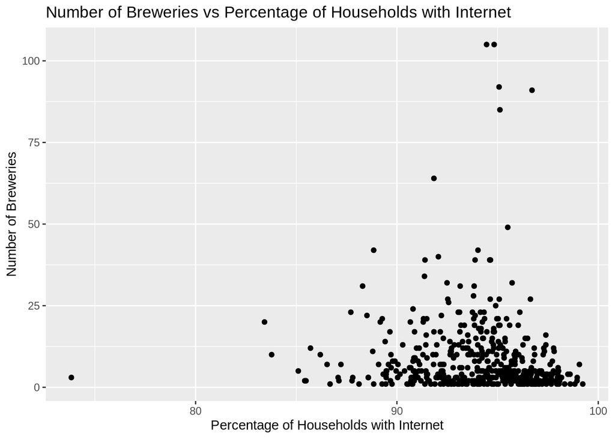

```r
library(ggplot2)

ggplot(breweries_and_computer_access) +
  geom_point(
    mapping = aes(
      x = percentage_of_households_with_internet,
      y = num_breweries
    )
  ) +
  labs(
    title = "Number of Breweries vs Percentage of Households with Internet",
    x = "Percentage of Households with Internet",
    y = "Number of Breweries"
  )
```

## Part V: Group Information

Our main topic of interest is looking at how different factors of daily life are influenced by technology access.

Lab Section BG, TA Lexeigh Kolakowski

Preethika Makineni (College of Arts & Sciences, intended Info minor; preethm@uw.edu) is interested in how data can measure correlations between tasks and objects in everyday life. She hopes to learn how informatics can support work in the humanities.

Shea Li (The Information School, University of Washington; siyuan61@uw.edu) is interesed in using data science to study social behavior. Sheis especially interested in infomatics applications that combine coding, communication, and real-world decision support.

### Coding Notes

We primarily used class demos and readings to inform our work, and referenced some additional functions from parsing through the online version of tidyverse at https://tidyverse.org/. We also pulled on previous learning from courses such as CSE163.